# Final_edits

Mohanad Elchouemi

4/15/2021

This R Markdown will show all the steps in my research up until April 15.

#### Loading Packages

Need a lot of packages for this.

```r
# if (!requireNamespace("BiocManager", quietly = TRUE))
#   install.packages("BiocManager")
#
# BiocManager::install("ribor")
# install.packages("lmodel2")
# install.packages("devtools")
# install_github("ribosomeprofiling/ribor")

library("devtools")
```

```r
library(ribor)
library(tidyr)
library(ggplot2)
library(FSA)
library(dplyr)
library(stringr)
library(janitor)
library(readxl)
library(ggplot2)
library("ggpubr")
library(lmodel2)
library(tidyverse)
```

#### Creating Ribo Object

Used the `ribor` library to create this object.

```r
second.ribo <- Ribo("/Users/mohanadelchouemi/Desktop/Dr Cenik/RibosomeTranslation/Cenik_Lab_ME/all.ribo", rename = rename_default )
second.ribo
```

```
## General File Information:
##              info
##    format version                1
##         reference        appris-v1
##   min read length               15
##   max read length               40
##         left span               35
##        right span               10
##  transcript count            19736
##      has.metadata             TRUE
##   metagene radius               50
##         has.alias             TRUE
##
## Dataset Information:
##   experiment total.reads    coverage     rna.seq    metadata
##   GSM1691202     3792821        TRUE        TRUE       FALSE
##   GSM1691203     4079528        TRUE        TRUE       FALSE
##   GSM1691204     4220124        TRUE        TRUE       FALSE
##   GSM1691205     4749014        TRUE        TRUE       FALSE
##   GSM1691206     6901556        TRUE        TRUE       FALSE
##   GSM1691207     3919586        TRUE        TRUE       FALSE
```

#### Creating mRNA dataframe

The data comes from the *GSM1691202* experiment in the ribo object, as this is what corresponds to the proteomics data.

```r
rna <- get_rnaseq(second.ribo,
           tidy = TRUE,
           region = c( "CDS"),
           experiment = "GSM1691202",
           compact = FALSE,
           alias = TRUE) %>% mutate(GENE_NAME3 = str_replace(transcript , "-.*",replacement = "")) %>%
  select(-c(transcript)) %>% select(count,GENE_NAME3) %>% rename(rna_count = count)
```

#### Creating Ribosomal Profiling Footprint dataframe

The data comes from the *GSM1691202* experiment in the ribo object, as this is what corresponds to the proteomics data.

```r
ribo_profiling <- get_region_counts(second.ribo,tidy = TRUE,
                        compact      = FALSE,
                        transcript  = FALSE,
                        alias       = TRUE,
                        region      = c("CDS"),
                        experiment ="GSM1691202") %>%
  mutate(GENE_NAME3 = str_replace(transcript , "-.*",replacement = "")) %>%
  select(-c(transcript)) %>% select(count,GENE_NAME3) %>%
  rename(ribo_count = count)
```

#### Creating Proteomic Dataframe

Data came from this paper: https://www.cell.com/cell-systems/pdfExtended/S2405-4712(17)30180-1

```r
data <- read_xlsx(path = "/Users/mohanadelchouemi/Desktop/Dr Cenik/RibosomeTranslation/Cenik_Lab_ME/mmc4.xlsx", sheet = 2) %>%
  mutate_at(vars(2:3),~as.numeric(.x ))
data[is.na(data)] <- 0
data$prot_count <- (data$`iBAQ 1 protein copies per cell` + data$`iBAQ 2 protein copies per cell`) / 2
proteomics <- data %>% select(`gene symbol`,prot_count) %>% rename(GENE_NAME3 = `gene symbol`)
```

### Running least squares regression models on the various techniques

####RNA-Seq vs Proteomics

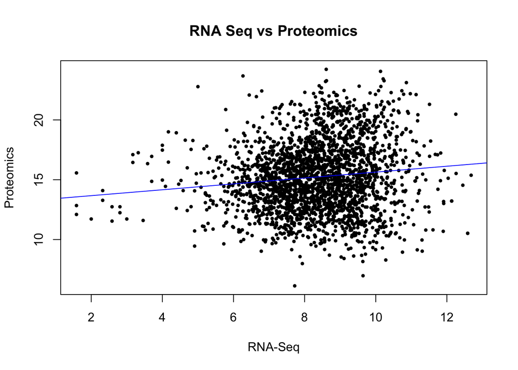

```r
rna_prot <- left_join(x = rna,y = proteomics, by = "GENE_NAME3") %>% na.omit() %>% .[.$rna_count > 2 & .$prot_count >2,]
plot(log2(rna_prot$rna_count), log2(rna_prot$prot_count), xlab = "RNA-Seq", ylab = "Proteomics", main = "RNA Seq vs Proteomics", pch = 19, cex = 0.5)
abline(lm(log2(rna_prot$prot_count) ~ log2(rna_prot$rna_count), data = rna_prot), col = "blue")
```

We calculated the R-Squared value, which tells us the proportion of the total variation of Proteomics in the sample that can be attributed to the linear relationship with RNA-Seq. This value was very low and was only 1.42%. And r was 0.1191916.

```r
cor(log2(rna_prot$rna_count), log2(rna_prot$prot_count), method = c("pearson"))^2 * 100
```

```
## [1] 1.420665
```

```r
cor(log2(rna_prot$rna_count), log2(rna_prot$prot_count), method = c("pearson"))
```

```
## [1] 0.1191916
```

Using Ranged Major Axis Regression we are able to use a regression that treats the x axis dependent and not just independent, which is what LS regression does. This takes into account that there might also be some degree of error in the X axis, which we are certain is the case.

```r
lmodel2(log2(prot_count) ~ log2(rna_count),  data = rna_prot,range.y = "relative",range.x = "relative",nperm = 1000)
```

```
##
## Model II regression
##
## Call: lmodel2(formula = log2(prot_count) ~ log2(rna_count), data =
## rna_prot, range.y = "relative", range.x = "relative", nperm = 1000)
##
## n = 2397   r = 0.1191916   r-square = 0.01420665
## Parametric P-values:   2-tailed = 4.817505e-09    1-tailed = 2.408752e-09
## Angle between the two OLS regression lines = 72.86115 degrees
##
## Permutation tests of OLS, MA, RMA slopes: 1-tailed, tail corresponding to sign
## A permutation test of r is equivalent to a permutation test of the OLS slope
## P-perm for SMA = NA because the SMA slope cannot be tested
##
## Regression results
##   Method  Intercept      Slope Angle (degrees) P-perm (1-tailed)
## 1    OLS  13.176123  0.2463278        13.83805       0.000999001
## 2     MA -96.322402 13.3541593        85.71751       0.000999001
## 3    SMA  -2.030276  2.0666529        64.17886                NA
## 4    RMA -14.424822  3.5503772        74.26958       0.000999001
##
## Confidence intervals
##   Method 2.5%-Intercept 97.5%-Intercept 2.5%-Slope 97.5%-Slope
## 1    OLS      12.479626       13.872621  0.1641082   0.3285474
## 2     MA    -152.083129      -68.359737 10.0068092  20.0291552
## 3    SMA      -2.730769       -1.357098  1.9860682   2.1505074
## 4    RMA     -27.959547       -6.499444  2.6016474   5.1705898
##
## Eigenvalues: 8.484761 1.941544
##
## H statistic used for computing C.I. of MA: 0.0006177801
```

Plotted both the least squared regression and the ranged major axis regression lines of best fit together. The black line is the RMA and the blue line is the LS.

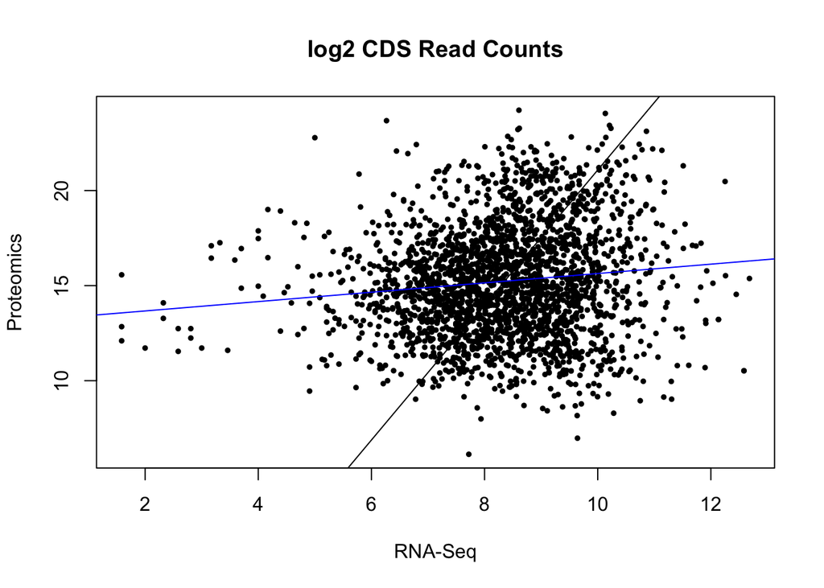

```r
plot(log2(rna_prot$rna_count), log2(rna_prot$prot_count), xlab = "RNA-Seq", ylab = "Proteomics", main = "log2 CDS Read Counts", pch = 19, cex = 0.5)
abline(-14.424822 ,3.5503772, col = "black")
abline(lm(log2(rna_prot$prot_count) ~ log2(rna_prot$rna_count), data = rna_prot), col = "blue")
```